# Time Series project, coursework

MarinelaSulaj

2024-03-10

## 1. Installing Packages

I first start off by installing packages by writing, `install.packages("prophet")`. However, I only need to do this once so I do not need to add these to my .Rmd file and run it.

Lets run and see what co2 is and we do this by running the r code, `?co2`, to have a better understanding.

In the description it is given that this data set provides a time series of the atmospheric CO2 concentrations measured in parts per million (ppm).

The format for this time series comprises 468 observations, which are recorded monthly from 1959 to 1997.

Details that have been provided are that the values for February, March, and April of 1964 were missing from the original data set and were interpolated linearly between the values for January and May of 1964.

### 1.2 What is the purpose of this project?

This data set serves as a valuable resource for studying long-term trends and variations in atmospheric CO2 concentrations, which are crucial for understanding the dynamics of climate change and its impacts on the environment. Additionally, the project includes predictions for future CO2 levels, by analysing these predictions, we can identify opportunities to improve our understanding of climate change dynamics and enhance our strategies for mitigating its effects on the environment.

## 2. Now we input the R codes

### 2.1 Data Frame

I create a data frame using, `data.frame()` and adding the named columns, then I store it in `co2.dataframe`. A way I convert the columns into a vector of dates, is by using the function, `yearmon()` from the ‘zoo’ library.

```r
co2.dataframe = data.frame(
  ds=zoo::as.yearmon(time(co2)),
  y=co2)
```

I use the prophet forecaster function, `prophet()`, to run the data frame, `co2.dataframe`. Once I store it in my function `Modelforecast`, I run the r code.

```r
Modelforecast = prophet::prophet(co2.dataframe, weekly.seasonality = TRUE, daily.seasonality = TRUE)
```

I now use the function, `Futuredates = make_future_dataframe(Modelforecast, 64)` to create future dates for forecasting, 64 indicates the number of periods ahead.

```r
Futuredates = prophet::make_future_dataframe(Modelforecast, periods=64, freq="quarter")
```

Then we use the function,`Predictmodel`, which is a versatile function designed for generating predictions based on the outcomes of diverse model fitting procedures. Where ‘Modelforecast’ is what we want the function to predict.

```r
Predictmodel = predict(Modelforecast, Futuredates)
```

## 3. Plotting and displaying the forecast

Finally, lets display the forecast by using `plot()`.

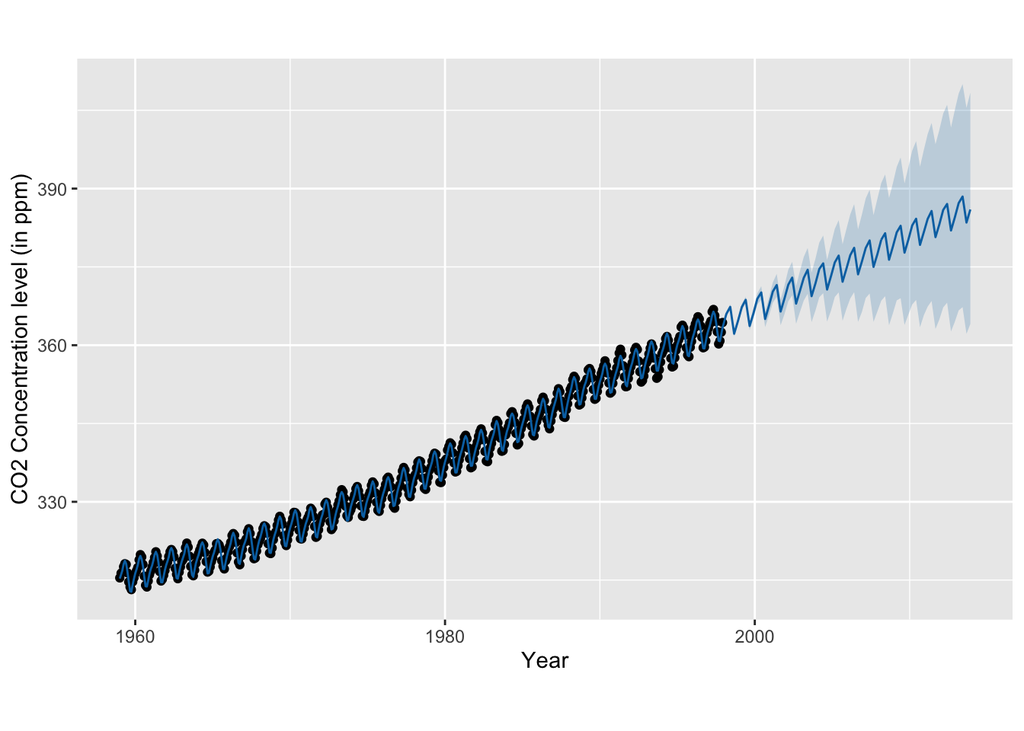

```r
plot(Modelforecast,Predictmodel, xlab = "Year",ylab = "CO2 Concentration level (in ppm)")
```

Now we have produced a plot of the co2 concentration levels and the forecast of co2, lets analyse what this tells us.

The black dots that form a zig zag shape are the 468 recorded values of the co2 concentration levels during the years of 1959 to 1997. You see that there is a zag zag shape which shows the fluctuations of co2 within the months of every year. Therefore, there must be varying factors that affected these fluctuations such as seasonal changes but as for the increase over the years it could be from population growth or industrial forms of work. You can clearly see that there is a positive correlation between the ‘co2 concentration levels’ and the ‘Years’ since as the years progressed there has been a steady increase in co2 concentration levels.

Due to this continuous pattern for 38 years, we used the r codes above to create predictions for the forthcoming years, which is the light blue line. The trend of co2 increasing steadily for 38 years has reflected on the predictions and it predicts that it will increase steadily following the zig zag shape. In addition, you see the light blue shadow projecting over the light blue line which may indicate the volume co2 may increase (or decrease) in 2013.

### 3.1 Interactive graph

```r
suppressWarnings(prophet::dyplot.prophet(Modelforecast, Predictmodel, main = " Interactive diagram of Co2 concentration levels with actual and predicted results",xlab = "Year",ylab = "CO2 Concentration levels (in ppm"))
```

[interactive chart not shown]

```r
# I used the function `suppressWarning()` to hide a warning generated by r that there may be a feature that needs checking.
```

I have now inputted an interactive dygraph so we can check the co2 concentration levels in a specific year obtaining actual values easier.

If we first hover over the last ‘actual’ point that was recorded in 1997 the value of co2 was 364.34 ppm but the predicted value is 363.34 ppm, something to take note of is by using the `predict` function r has followed the trend of over the years and has created an underestimate of the actual values because it is forming linear predictions as close to the points as possible. You can see there may be a few outliers just outside the predicted line but this is nothing to be alarmed of as the predicted line tries to follow the trend as close to the actual values as possible.

Furthermore, if we pick the highest point in the 1997 actual results it was recorded to have 366.85 ppm. The plot predicted that there would be a 5.22% increase from 1997 to 2013 which follows a similar pattern as above.

Overall, using the actual results and the predictions, the will be an increase of 22.42% of the co2 concentration levels over 54 years.

### 3.2 Further Forecasts

Why don’t we look at further forecasts in detail.

Here we use the `prophet_plot_components()` to plot other components such as ‘trend’, ‘weekly’, ‘yearly’ and ’daily data. By analysing these we can obtain a better understanding of co2 concentration levels over the years, during the week, within a year and during the day.

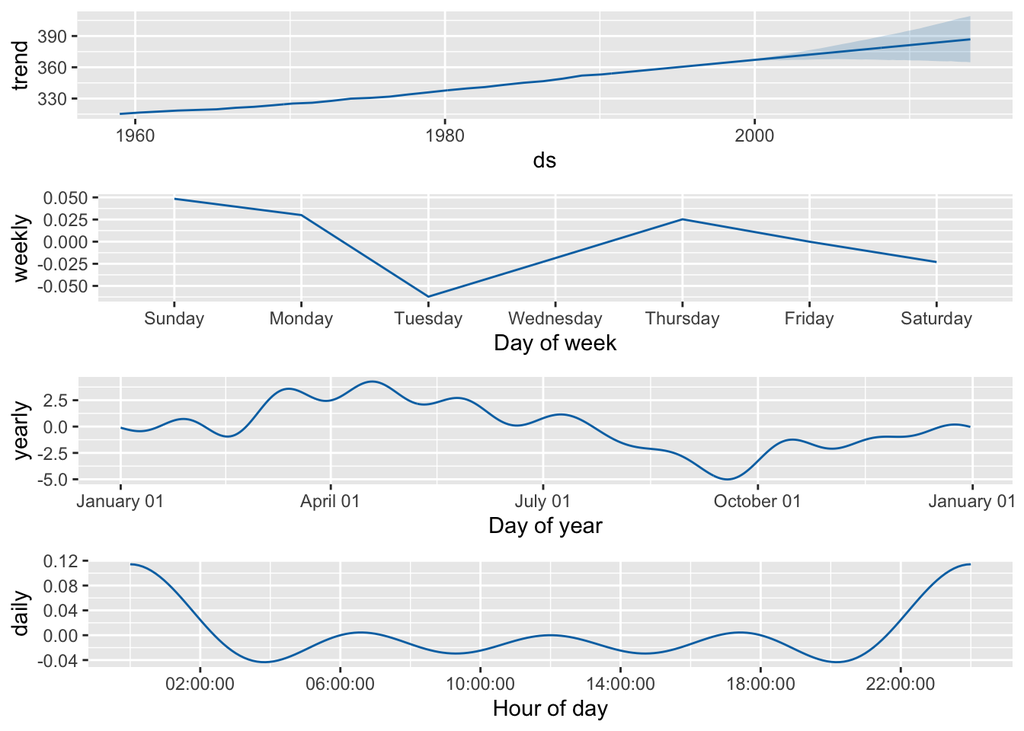

```r
prophet::prophet_plot_components(Modelforecast,Predictmodel)
```

Now we have plotted all the components, lets look into detail of what these graphs are telling us.

### Diagram 1 - Trend

As we have previously analysed, there is a positive correlation between the years and the level of co2 from 1959 to 2013. This shows a growing trend during this period of time and the level of co2 may continue to grow basing on this trend. Further research should be conducted to understand in depth as to why levels will vary

### Diagram 2 - Weekly

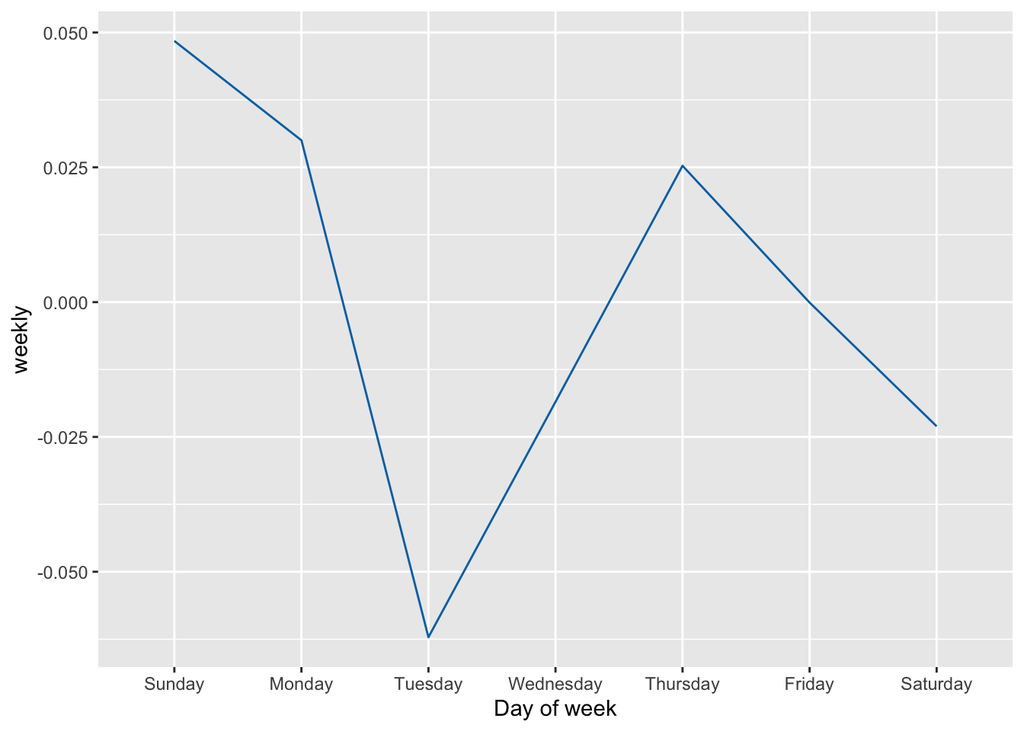

```r
prophet:::plot_weekly(Modelforecast)
```

Diagram 2 is the weekly patterns of co2 levels from Sunday to Saturday. The highest point of co2 concentration levels are on Sunday and the lowest being on Tuesday. Throughout the week there are many fluctuations and it does not follow a particular linear pattern.

### Diagram 3 - Yearly

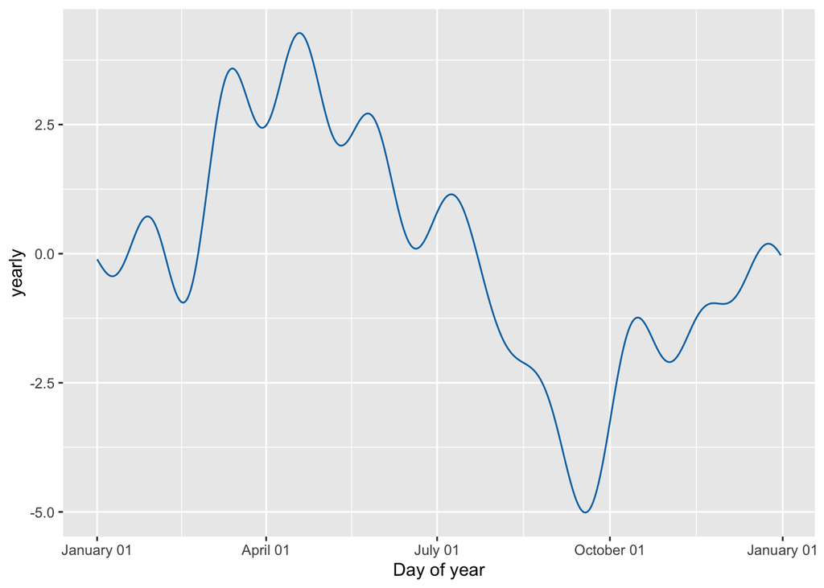

```r
prophet:::plot_yearly(Modelforecast)
```

Moving onto diagram 3, this shows the yearly patterns of co2 levels from the beginning of the year, January 01 to the beginning of the following year January 01. We again see many fluctuations throughout the year, one particular fluctuation that stands out is the sudden dip from July 01 to the end of September.

What factors could be causing this? The dip starts just after July which is the beginning of Summer until the start of Autumn, this may be the time where there are seasonal changes from plants such as flowers and vegetables, because they are actively growing which may affect the co2 levels during those particular months. This can lead to a temporary decrease in atmospheric CO2 levels.

CO2 levels tend to rise from January to May. This could be because we are more active at the start of the year, with work commitments and other activities increasing. However, as July approaches and the school year ends as well, along with people taking vacations, our overall activity may decrease. This reduction in activity could contribute to the observed dip in CO2 levels during that time.

### 3.3 Linear Regression

For further understanding of how linear co2 is with time, we run a linear regression model to gain an understanding of the growth.

```r
linear.model <- lm(y ~ ds, data = co2.dataframe)
summary(linear.model)
```

```
##
## Call:
## lm(formula = y ~ ds, data = co2.dataframe)
##
## Residuals:
##     Min      1Q  Median      3Q     Max
## -6.0399 -1.9476 -0.0017  1.9113  6.5149
##
## Coefficients:
##               Estimate Std. Error t value Pr(>|t|)
## (Intercept) -2.250e+03  2.127e+01  -105.8   <2e-16 ***
## ds           1.308e+00  1.075e-02   121.6   <2e-16 ***
## ---
## Signif. codes:  0 '***' 0.001 '**' 0.01 '*' 0.05 '.' 0.1 ' ' 1
##
## Residual standard error: 2.618 on 466 degrees of freedom
## Multiple R-squared:  0.9695, Adjusted R-squared:  0.9694
## F-statistic: 1.479e+04 on 1 and 466 DF,  p-value: < 2.2e-16
```

This analysis suggests that there is a strong linear relationship between time and CO2 concentrations, as displayed by the diagrams in the beginning. The positive coefficient for the ds variable (representing time) 1.308e+00 indicates that co2 concentrations are increasing over time. The high R-squared value of 0.9695 indicates that the linear regression model explains a large proportion of the variance in co2 concentrations. Overall, the linear regression analysis provides valuable insights into the trend of co2 concentrations over time.